# Team 80 - There Goes the Neighborhood: Predicting Gentrification in the United States

One of the biggest challenges with gentrification is that people are not aware that it is happening in a community until it is too late to address it and native residents have already been displaced. If local governments are aware that their communities are likely to become gentrified, they can allocate resources, gather community input and enact policies to avoid widespread displacement of native residents. In this project, we develop a model to predict which U.S. counties are at risk of becoming gentrified based on several predictors.

```
## x psych::%+%()      masks ggplot2::%+%()
```

Our main dataset is sourced from the “2020 Healthiest Communities rankings”. The 2020 Healthiest Communities rankings were created in collaboration with the Aetna Foundation, an independent affiliate of CVS Health. The University of Missouri Extension Crnter for Applied Research and Engagement Systems performed data collection and analysis. This data is publicly available through the following website which has a profile for each U.S. county and shows their respective performance across 84 metrics in 10 categories (Population Health, Equity, Education, Economy, Housing, Food & Nutrition, Environment, Public Safety, Community Vitality, and Infrastructure): https://www.usnews.com/news/healthiest-communities/district-of-columbia/district-of-columbia

First, we load in our data after we have webscarped it and notice that it is tall.

```r
df <- read.csv("https://raw.githubusercontent.com/omarp120/Predicting-Gentrification/main/us_news_factors.csv")
head(df)
```

```
##   X       County_Name State_Name
## 1 0 los-alamos-county new-mexico
## 2 1 los-alamos-county new-mexico
## 3 2 los-alamos-county new-mexico
## 4 3 los-alamos-county new-mexico
## 5 4 los-alamos-county new-mexico
## 6 5 los-alamos-county new-mexico
##                                               Variables County    US Peer_Group
## 1                         Hospital Bed Availability /1k    2.8   2.0        2.1
## 2                   Population With No Health Insurance   3.0% 10.6%       8.1%
## 3                Primary Care Doctor Availability /100k    2.5   1.1        1.5
## 4         Adults With No Leisure-Time Physical Activity  12.5% 25.9%      22.9%
## 5 Medicare Beneficiaries With Recent Primary Care Visit  31.0% 21.0%      27.0%
## 6                                          Smoking Rate  10.0% 17.3%      15.6%
##   State
## 1   3.0
## 2 11.0%
## 3   1.6
## 4 19.3%
## 5 14.6%
## 6 15.5%
```

We also drop any columns that we will not use at this time, like the state and peer group comparisons for each county.

```r
df2 <- subset(df, select = c(County_Name, State_Name, Variables, County))
head(df2)
```

```
##         County_Name State_Name
## 1 los-alamos-county new-mexico
## 2 los-alamos-county new-mexico
## 3 los-alamos-county new-mexico
## 4 los-alamos-county new-mexico
## 5 los-alamos-county new-mexico
## 6 los-alamos-county new-mexico
##                                               Variables County
## 1                         Hospital Bed Availability /1k    2.8
## 2                   Population With No Health Insurance   3.0%
## 3                Primary Care Doctor Availability /100k    2.5
## 4         Adults With No Leisure-Time Physical Activity  12.5%
## 5 Medicare Beneficiaries With Recent Primary Care Visit  31.0%
## 6                                          Smoking Rate  10.0%
```

Here we transform our data from tall to wide so that each column represents a variable. We have a total of 500 counties and 84 different variables that we can use as inputs for our model.

```r
df_wide <- df2 %>% spread(Variables, County)
head(df_wide)
```

```
##        County_Name State_Name Accidental Death Rate /100k
## 1       ada-county      idaho                        37.8
## 2     adair-county       iowa                        50.3
## 3   addison-county    vermont                        45.2
## 4   alameda-county california                        24.7
## 5    albany-county    wyoming                        49.2
## 6 albemarle-county   virginia                        32.6
##   Adults in Poor or Fair General Health
## 1                                 11.6%
## 2                                 11.7%
## 3                                 11.4%
## 4                                 12.7%
## 5                                 16.0%
## 6                                 12.9%
##   Adults With No Leisure-Time Physical Activity Affordable Housing Shortfall
```

[output cut: 293 more lines]

In this section, we export our file to Excel so that we can convert our variables to the correct numerical formats and ratios (double or integrer), and then we re-import our file into R. This will allow us to properly impute missing values.

```r
#write.csv(df_wide, 'all-us-counties-transformed.csv')
df_trans <- read.csv("all-us-counties-transformed.csv")
head(df_trans)
```

```
##          County_me   State_me AccidentalDeathRate
## 1       ada-county      idaho            0.000378
## 2     adair-county       iowa            0.000503
## 3   addison-county    vermont            0.000452
## 4   alameda-county california            0.000247
## 5    albany-county    wyoming            0.000492
## 6 albemarle-county   virginia            0.000326
##   AdultsinPoororFairGeneralHealth AdultsWithNoLeisure.TimePhysicalActivity
## 1                           0.116                                    0.146
## 2                           0.117                                    0.252
## 3                           0.114                                    0.192
## 4                           0.127                                    0.145
## 5                           0.160                                    0.176
## 6                           0.129                                    0.169
##   AffordableHousingShortfall Air.QualityHazard
```

[output cut: 244 more lines]

Next, we use KNN imputation to fill in any missing values, using the nearest 2 neighbors to approximate the values to impute with.

```r
df_imputed <- knnImputation(df_trans[,3:86], k=2)
```

Here we calculate some summary statistics for all of our variables.

```r
summary(df_imputed)
```

```
##  AccidentalDeathRate AdultsinPoororFairGeneralHealth
##  Min.   :0.0001910   Min.   :0.0830
##  1st Qu.:0.0003658   1st Qu.:0.1130
##  Median :0.0004395   Median :0.1225
##  Mean   :0.0004448   Mean   :0.1241
##  3rd Qu.:0.0005144   3rd Qu.:0.1330
##  Max.   :0.0009590   Max.   :0.2690
##  AdultsWithNoLeisure.TimePhysicalActivity AffordableHousingShortfall
##  Min.   :0.0940                           Min.   :-96.00
##  1st Qu.:0.1790                           1st Qu.:-67.90
##  Median :0.2075                           Median :-54.35
##  Mean   :0.2100                           Mean   :-50.73
##  3rd Qu.:0.2400                           3rd Qu.:-38.10
##  Max.   :0.3370                           Max.   : 52.80
##  Air.QualityHazard AirToxicsExposureDisparityIndexScore AirborneCancerRisk
##  Min.   :0.1000    Min.   : 0.000                       Min.   :  9.35
##  1st Qu.:0.2200    1st Qu.: 1.038                       1st Qu.: 17.46
##  Median :0.2700    Median : 2.272                       Median : 21.20
##  Mean   :0.3173    Mean   : 2.780                       Mean   : 25.07
##  3rd Qu.:0.4000    3rd Qu.: 3.842                       3rd Qu.: 28.53
##  Max.   :1.5000    Max.   :21.900                       Max.   :525.56
##  AreaWithTreeCanopy AverageWeeklyWage BabiesBornWithLowBirthWeight
##  Min.   :0.0000     Min.   : 570.0    Min.   :0.02600
##  1st Qu.:0.0290     1st Qu.: 744.8    1st Qu.:0.05900
##  Median :0.0945     Median : 834.0    Median :0.06500
##  Mean   :0.1685     Mean   : 897.4    Mean   :0.06646
##  3rd Qu.:0.2592     3rd Qu.: 970.5    3rd Qu.:0.07300
##  Max.   :0.7920     Max.   :2590.0    Max.   :0.12600
##  BusinessGrowthRate CancerIncidenceRate CensusSelf.ResponseRate
##  Min.   :0.00900    Min.   :0.002410    Min.   :0.3540
##  1st Qu.:0.06600    1st Qu.:0.004123    1st Qu.:0.6980
##  Median :0.08500    Median :0.004491    Median :0.7270
##  Mean   :0.08321    Mean   :0.004420    Mean   :0.7255
##  3rd Qu.:0.10400    3rd Qu.:0.004745    3rd Qu.:0.7610
##  Max.   :0.18700    Max.   :0.005932    Max.   :1.0000
##  ChangeinHousingValue ChildCareFacilitiesRate
##  Min.   :-0.04200     Min.   :0.000e+00
##  1st Qu.: 0.06275     1st Qu.:2.400e-05
##  Median : 0.11700     Median :5.600e-05
##  Mean   : 0.13795     Mean   :9.309e-05
```

[output cut: 204 more lines]

```
##  Max.   :6.540e-04        Max.   :0.007605      Max.   :0.8790
##  WalkabilityIndexScore WorkHoursNeededtoPayforAffordableHousing
##  Min.   : 3.200        Min.   : 18.00
##  1st Qu.: 6.200        1st Qu.: 37.00
##  Median : 6.700        Median : 43.00
##  Mean   : 7.247        Mean   : 45.44
##  3rd Qu.: 7.700        3rd Qu.: 51.00
##  Max.   :16.200        Max.   :112.00
##  WorkersCommuting60MinutesorMore YouthWithin5MilesofaPublicSchool
##  Min.   :0.00700                 Min.   :0.3670
##  1st Qu.:0.03700                 1st Qu.:0.7268
##  Median :0.05150                 Median :0.8475
##  Mean   :0.07044                 Mean   :0.8297
##  3rd Qu.:0.08425                 3rd Qu.:0.9650
##  Max.   :0.34800                 Max.   :1.0000
```

There are too many different correlation pairs to attempt observing as we have 84 different variables, so we instead look at which variables have the strongest relationships in our dataset.

Below are the top 20 strongest correlation pairs in our dataset. It appears that the two variables with the strongest correlation are NeighborhoodDisparityinEducationAttainment and PopulationWithAdvancedDegree.

```r
#devtools::install_github("laresbernardo/lares")
library(lares)

corr_cross(df_imputed, # name of dataset
  max_pvalue = 0.05, # display only significant correlations (at 5% level)
  top = 20
)
```

```
## Returning only the top 20. You may override with the 'top' argument
```

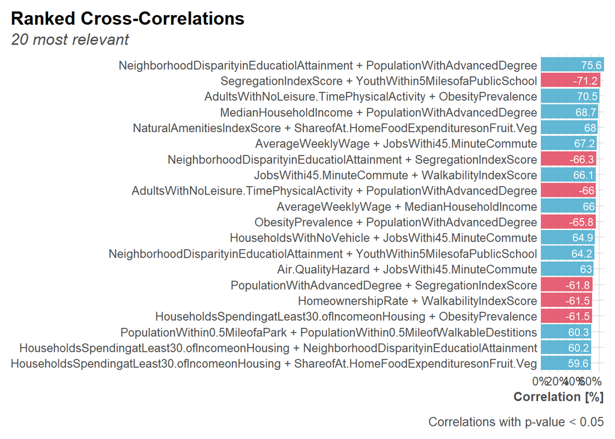

Next, we look at which variables are most highly correlated with our ‘AffordableHousingShortfall’ variable which is our proxy variable for predicting gentrification. The data source defines this variable as the “Availability of affordable housing relative to a community’s low-income population. Negative numbers indicate a shortfall.”

It appears that “Households Spending at least 30% of income on Housing” is the strongest predictor of an affordable housing shortfall, or gentrification.

```r
corr_var(df_imputed, # name of dataset
  AffordableHousingShortfall, # name of variable to focus on
  top = 15 # display top 5 correlations
)
```

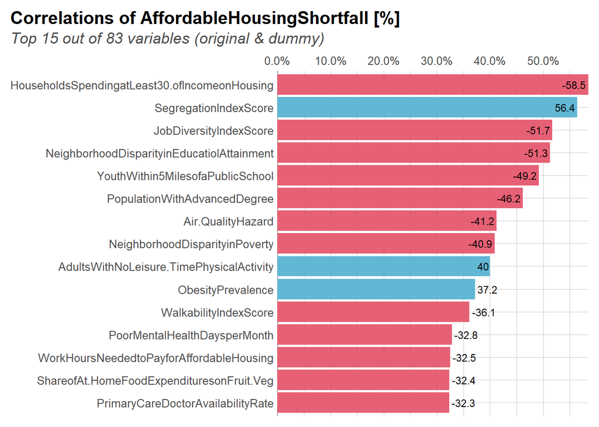

Next, we work on developing 7 different models for predicting gentrification using our proxy AffordableHousingShortfall variable. We will select the “best” model by evaluating them in terms of their RMSE.

We start by splitting our data into a training and test set, using 80% of our data to train our models and holding out 20% to test them.

```r
#data splitting
set.seed(101)

sample = sample.split(df_imputed$AffordableHousingShortfall, SplitRatio = .8)

train = subset(df_imputed, sample == TRUE)
test  = subset(df_imputed, sample == FALSE)

train_X = subset(train, select = -AffordableHousingShortfall)
train_y = train[,'AffordableHousingShortfall']

test_X = subset(test, select = -AffordableHousingShortfall)
test_y = test[,'AffordableHousingShortfall']
```

## Linear Regression Model

Linear regression is an attractive model because representation is simply done. The representation is a linear equation that combines a specific set of input values (x) the solution to which is the predicted output for that set of input values (y). In this instance, we will be predicting AffordableHousingShortfall values through three different linear regression techniques.

### GLM

The generalized linear model (GLM) is a flexible generalization of ordinary linear regression that allows for response variables that have error distribution models other than a normal distribution. The GLM generalizes linear regression by allowing the linear model to be related to the response variable via a link function and by allowing the magnitude of the variance of each measurement to be a function of its predicted value.

```r
control = trainControl(method = 'cv', number = 5,
  verboseIter = FALSE, savePredictions = TRUE,allowParallel = T)
```

```r
set.seed(17)
GLM_train = train(AffordableHousingShortfall ~ ., data = train, metric = 'RMSE', method = 'glm',preProcess = c('center', 'scale'), trControl = control)
GLM_reg_pred <- predict(GLM_train, test_X)

GLM_train
```

```
## Generalized Linear Model
##
## 400 samples
##  83 predictor
##
## Pre-processing: centered (83), scaled (83)
## Resampling: Cross-Validated (5 fold)
## Summary of sample sizes: 320, 320, 320, 320, 320
## Resampling results:
##
##   RMSE      Rsquared   MAE
##   19.19956  0.4346039  13.68569
```

Using RMSE as a benchmark for linear regression modelling, we determined our GLM model performed quite well at 19.2. We will attempt two other iterations with different linear techniques to determine if our baseline can be improved.

### glmnet

glmnet is an extremely efficient procedure for fitting the entire lasso or elastic-net regularization path for linear regression, logistic and multinomial regression models, Poisson regression and the Cox model. Two recent additions are the multiple-response Gaussian, and the grouped multinomial regression. The algorithm uses cyclical coordinate descent in a path-wise fashion to determine the best linear fit.

```r
set.seed(17)
glmnet_train = train(AffordableHousingShortfall ~ ., data = train , metric = 'RMSE', method = 'glmnet',preProcess = c('center', 'scale'), trControl = control)
glmnet_reg_pred <- predict(glmnet_train, test_X)

glmnet_train
```

```
## glmnet
##
## 400 samples
##  83 predictor
##
## Pre-processing: centered (83), scaled (83)
## Resampling: Cross-Validated (5 fold)
## Summary of sample sizes: 320, 320, 320, 320, 320
## Resampling results across tuning parameters:
##
##   alpha  lambda      RMSE      Rsquared   MAE
##   0.10   0.02846147  19.12225  0.4370419  13.63454
##   0.10   0.28461473  18.73773  0.4488048  13.37479
##   0.10   2.84614733  17.73569  0.4756701  12.57925
##   0.55   0.02846147  19.04562  0.4395182  13.57765
##   0.55   0.28461473  18.30699  0.4588184  13.05158
##   0.55   2.84614733  17.60362  0.4802538  12.55867
##   1.00   0.02846147  18.96178  0.4421959  13.51636
##   1.00   0.28461473  18.03679  0.4643275  12.84684
##   1.00   2.84614733  18.11644  0.4569902  13.00166
##
## RMSE was used to select the optimal model using the smallest value.
## The final values used for the model were alpha = 0.55 and lambda = 2.846147.
```

### Partial Least Squares

Partial least squares (PLS) is a method for constructing predictive models when the factors are many and highly collinear. Partial least squares is a popular method for soft modelling in industrial applications. We believed that it would be an effective model to demonstrate.

```r
set.seed(17)
pls_train = train(AffordableHousingShortfall ~ ., data = train , metric = 'RMSE', method = 'pls',preProcess = c('center', 'scale'), trControl = control)
pls_reg_pred <- predict(pls_train, test_X)

pls_train
```

```
## Partial Least Squares
##
## 400 samples
##  83 predictor
##
## Pre-processing: centered (83), scaled (83)
## Resampling: Cross-Validated (5 fold)
## Summary of sample sizes: 320, 320, 320, 320, 320
## Resampling results across tuning parameters:
##
##   ncomp  RMSE      Rsquared   MAE
##   1      18.99295  0.3939885  13.54142
##   2      18.11396  0.4505461  12.81498
##   3      18.22649  0.4573401  12.98211
##
## RMSE was used to select the optimal model using the smallest value.
## The final value used for the model was ncomp = 2.
```

The final value used for the model was ncomp = 2, and it produced an RMSE of 18.11. The GLM Net model outperformed this with a RMSE of 17.6.

## Non-linear Regression Models

In this section, we are going to fit a simple neural network using the neuralnet package.

Here we confirm that there are no more empty data:

```r
#describe(bev)
apply(df_imputed,2,function(x) sum(is.na(x)))
```

```
##                                         AccidentalDeathRate
##                                                           0
##                             AdultsinPoororFairGeneralHealth
##                                                           0
##                    AdultsWithNoLeisure.TimePhysicalActivity
##                                                           0
##                                  AffordableHousingShortfall
##                                                           0
##                                           Air.QualityHazard
##                                                           0
##                        AirToxicsExposureDisparityIndexScore
##                                                           0
##                                          AirborneCancerRisk
##                                                           0
##                                          AreaWithTreeCanopy
##                                                           0
##                                           AverageWeeklyWage
##                                                           0
##                                BabiesBornWithLowBirthWeight
##                                                           0
##                                          BusinessGrowthRate
##                                                           0
##                                         CancerIncidenceRate
##                                                           0
##                                     CensusSelf.ResponseRate
##                                                           0
##                                        ChangeinHousingValue
##                                                           0
##                                     ChildCareFacilitiesRate
##                                                           0
##                     ChildrenMeetingStandardsinGrade4ELARate
##                                                           0
##       ContinuingEducationTaxCreditsasShareofTotalTaxFilings
##                                                           0
##                                         DeathsofDespairRate
##                                                           0
##                                          DiabetesPrevalence
##                                                           0
##                                     DisabilityEmploymentGap
##                                                           0
```

[output cut: 113 more lines]

```
##                                                           0
##                                    VehicleCrashFatalityRate
##                                                           0
##                                       ViolentCrimeRate.100k
##                                                           0
##                                      VoterParticipationRate
##                                                           0
##                                       WalkabilityIndexScore
##                                                           0
##                    WorkHoursNeededtoPayforAffordableHousing
##                                                           0
##                             WorkersCommuting60MinutesorMore
##                                                           0
##                            YouthWithin5MilesofaPublicSchool
##                                                           0
```

### Preparing to fit the neural network

Before fitting a neural network, some preparation needs to be done.

As a first step, we are going to address data preprocessing. We will be normalizing the data before training a neural network. We chose to use the min-max method and scale the data in the interval [0,1]. Usually scaling in the intervals [0,1] or [-1,1] tends to give better results.

We therefore scale and split the data before moving on:

```r
maxs <- apply(df_imputed, 2, max)
mins <- apply(df_imputed, 2, min)
```

Scaled returns a matrix that needs to be coerced into a data.frame.

```r
scaled <- as.data.frame(scale(df_imputed, center = mins, scale = maxs - mins))
#scaled
index <- sample(1:nrow(df_imputed),round(0.75*nrow(df_imputed)))
train_ <- scaled[index,]
test_ <- scaled[-index,]
```

### Parameters

In this dataset, we are going to use 2 hidden layers with this configuration: 83:5:3:1. The input layer has 83 inputs, the two hidden layers have 5 and 3 neurons and the output layer has, of course, a single output since we are doing regression.

Let’s fit the net: Setting the linear.output = True does regression instead of classification.

```r
n <- names(train_)
f <- as.formula(paste("AffordableHousingShortfall ~", paste(n[!n %in% "AffordableHousingShortfall"], collapse = " + ")))
nn <- neuralnet(f,data=train_,hidden=c(5,3),linear.output=T)
```

### Plot the Neural Network

```r
plot(nn)
```

[output not shown]

### Predicting AffordableHousingShortfall using the neural network

Now we can try to predict the values for the test set and calculate the RMSE. The net will output a normalized prediction, so we need to scale it back in order to make a meaningful comparison (or just a simple prediction).

```r
pr.nn <- compute(nn,test_[,1:84])
pr.nn_ <- pr.nn$net.result*(max(df_imputed$AffordableHousingShortfall)-min(df_imputed$AffordableHousingShortfall))+min(df_imputed$AffordableHousingShortfall)
test.r <- (test_$AffordableHousingShortfall)*(max(df_imputed$AffordableHousingShortfall)-min(df_imputed$AffordableHousingShortfall))+min(df_imputed$AffordableHousingShortfall)
MSE.nn <- sum((test.r - pr.nn_)^2)/nrow(test_)
```

The RMSE for our Neural Network is 31.55 which does not perform as well as our GLM net model.

```r
nn.rmse <- sqrt(MSE.nn)
print(nn.rmse)
```

```
## [1] 31.54765
```

## Tree Models

In this next section, we consider various tree models to predict the AffordableHousingShortfall, or gentrification, of a U.S. county given the 83 other indicators.

### Basic Regression Tree

Classification and regression trees can be generated througn rpart to create simple tree models. Tree-based models consist of one or more nested if-then statements for the predictors that partition the data. A model is used to predict the outcome within these partitions.

```r
treeb <- train(x = train_X, y = train_y, method = "rpart", preProcess = c('center', 'scale'))
treeb
```

```
## CART
##
## 400 samples
##  83 predictor
##
## Pre-processing: centered (83), scaled (83)
## Resampling: Bootstrapped (25 reps)
## Summary of sample sizes: 400, 400, 400, 400, 400, 400, ...
## Resampling results across tuning parameters:
##
##   cp          RMSE      Rsquared   MAE
##   0.06071757  21.18997  0.2847308  15.21984
##   0.07429463  21.34260  0.2719466  15.34983
##   0.32829427  21.59173  0.2794404  15.95130
##
## RMSE was used to select the optimal model using the smallest value.
## The final value used for the model was cp = 0.06071757.
```

```r
treebPred <- predict(treeb, newdata = test_X)
treeb.results <- postResample(pred = treebPred, obs = test_y)
treeb.results
```

```
##       RMSE   Rsquared        MAE
## 24.0467330  0.1727561 17.6478419
```

The RMSE for this basic regression tree model is 24.05 with an RM^2 of 0.17.

We also plot this specific tree below:

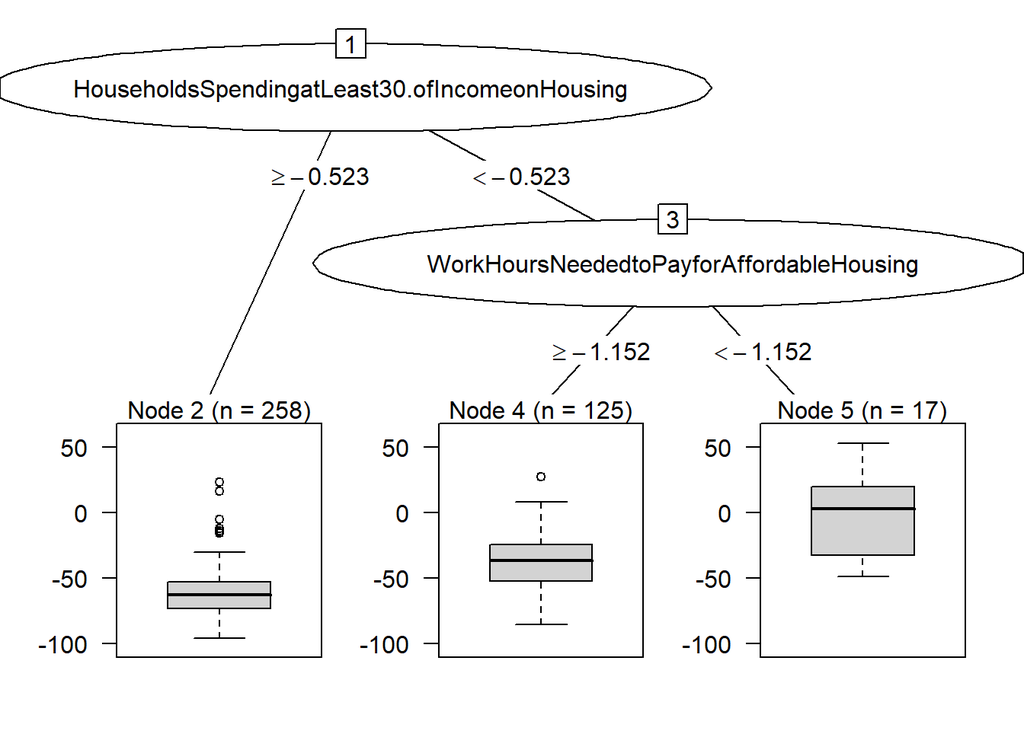

```r
plot(as.party(treeb$finalModel))
```

Next, we will try out a Random Forest model to see if we can improve upon this model.

### Random Forest

Random Forest is an ensemble model where each tree splits out a class prediction and the class with the most contributions becomes the model’s prediction value. Random Forest creates as many trees on the subset of the data and combines the output of all the trees. This thus reduces problems in overfitting and reduces the variance.

```r
rf <- train(x = train_X, y = train_y, method = "rf", preProcess = c('center', 'scale'))
rf
```

```
## Random Forest
##
## 400 samples
##  83 predictor
##
## Pre-processing: centered (83), scaled (83)
## Resampling: Bootstrapped (25 reps)
## Summary of sample sizes: 400, 400, 400, 400, 400, 400, ...
## Resampling results across tuning parameters:
##
##   mtry  RMSE      Rsquared   MAE
##    2    18.49052  0.4460399  12.84827
##   42    18.01823  0.4521409  12.43415
##   83    18.27414  0.4352865  12.62710
##
## RMSE was used to select the optimal model using the smallest value.
## The final value used for the model was mtry = 42.
```

```r
rfPred <- predict(rf, newdata = test_X)
rf.results <- postResample(pred = rfPred, obs = test_y)
rf.results
```

```
##       RMSE   Rsquared        MAE
## 18.8211486  0.4164222 13.3131592
```

The RMSE for this model is 18.82 with a RM^2 of 0.416. This Random Forest model performes better than our Basic Regression Tree model. We will also consider an XGBoost model to see if we can find any improvements.

### XGBoost

XGBoost is another ensemble model, this time using the gradient boosting framework which is a special case of boosting where errors are minimized by gradient descent algorithm. XGBoost only manages numeric vectors, and luckily all of our variables are numeric.

```r
xgb <- train(x = train_X, y = train_y, method = "xgbTree")
```

[output not shown]

[output cut: 846 more lines]

[output not shown]

```r
xgb
```

```
## eXtreme Gradient Boosting
##
## 400 samples
##  83 predictor
##
## No pre-processing
## Resampling: Bootstrapped (25 reps)
## Summary of sample sizes: 400, 400, 400, 400, 400, 400, ...
## Resampling results across tuning parameters:
##
##   eta  max_depth  colsample_bytree  subsample  nrounds  RMSE      Rsquared
##   0.3  1          0.6               0.50        50      18.94796  0.4052137
##   0.3  1          0.6               0.50       100      19.38501  0.3940234
##   0.3  1          0.6               0.50       150      19.59281  0.3900588
##   0.3  1          0.6               0.75        50      18.65452  0.4201367
##   0.3  1          0.6               0.75       100      18.95615  0.4123897
##   0.3  1          0.6               0.75       150      19.20493  0.4045784
##   0.3  1          0.6               1.00        50      18.55914  0.4222477
##   0.3  1          0.6               1.00       100      18.79256  0.4169608
##   0.3  1          0.6               1.00       150      18.92401  0.4141411
##   0.3  1          0.8               0.50        50      18.88343  0.4098330
##   0.3  1          0.8               0.50       100      19.21140  0.4013811
##   0.3  1          0.8               0.50       150      19.54423  0.3912959
##   0.3  1          0.8               0.75        50      18.63041  0.4223559
##   0.3  1          0.8               0.75       100      19.02423  0.4099619
##   0.3  1          0.8               0.75       150      19.24073  0.4034291
##   0.3  1          0.8               1.00        50      18.62808  0.4194252
##   0.3  1          0.8               1.00       100      18.82563  0.4159255
##   0.3  1          0.8               1.00       150      18.99230  0.4125945
##   0.3  2          0.6               0.50        50      19.67618  0.3782204
##   0.3  2          0.6               0.50       100      20.01380  0.3691968
##   0.3  2          0.6               0.50       150      20.07028  0.3676065
##   0.3  2          0.6               0.75        50      19.03961  0.4025731
##   0.3  2          0.6               0.75       100      19.14765  0.4014763
##   0.3  2          0.6               0.75       150      19.19331  0.4001603
##   0.3  2          0.6               1.00        50      18.75274  0.4156204
##   0.3  2          0.6               1.00       100      18.89743  0.4124225
##   0.3  2          0.6               1.00       150      18.96594  0.4100977
##   0.3  2          0.8               0.50        50      19.49059  0.3857508
##   0.3  2          0.8               0.50       100      19.74933  0.3785317
```

[output cut: 181 more lines]

```
##   14.84785
##   14.29798
##   14.30197
##   14.30078
##   13.61699
##   13.63309
##   13.63580
##
## Tuning parameter 'gamma' was held constant at a value of 0
## Tuning
##  parameter 'min_child_weight' was held constant at a value of 1
## RMSE was used to select the optimal model using the smallest value.
## The final values used for the model were nrounds = 50, max_depth = 1, eta
##  = 0.3, gamma = 0, colsample_bytree = 0.6, min_child_weight = 1 and subsample
##  = 1.
```

```r
xgbPred <- predict(xgb, newdata = test_X)
xgb.results <- postResample(pred = xgbPred, obs = test_y)
xgb.results
```

```
##       RMSE   Rsquared        MAE
## 20.0079475  0.3574677 14.1354080
```

The RMSE for this model is 20.01 with a RM^2 of 0.357.

We considered Basic Regression, Random Forest and XGBoost tree models, and Random Forest performed the best out of the three in predicting AffordableHousingShortfall as it had the smallest RMSE value at 18.82 with a RM^2 of 0.416.

## Conclusion

Finally, we will choose our best model for predicting AffordableHousingShortfall among the chosen Linear (GLM Net), Non-Linear (Neural Network) and Tree Models (Random Forest) that we have gone over in this analysis. Their RMSE metrics are summarized here:

```r
lin_model_perf <- getTrainPerf(glmnet_train)
print(lin_model_perf)
```

```
##   TrainRMSE TrainRsquared TrainMAE method
## 1  17.60362     0.4802538 12.55867 glmnet
```

```r
print(nn.rmse)
```

```
## [1] 31.54765
```

```r
rf_perf <- as.data.frame(as.list(rf.results))
print(rf_perf)
```

```
##       RMSE  Rsquared      MAE
## 1 18.82115 0.4164222 13.31316
```

The RMSE for the chosen Linear Model (GLM Net) was 17.604. The RMSE for the chosen Non-Linear Model (Neural Net) was 31.54. And lastly, the RMSE for the chosen Tree model (Random Forest) was 18.82. So, we chose the GLM Net Model as our final model to predict the AffordableHousingShortfall of our counties given the predictors on hand.

In this final chosen GLM Net model, the top 5 predictors that we found to influence AffordableHousingShortfall, or gentrification, for counties are HouseholdsSpendingatLeast30.ofIncomeonHousing, SegregationIndexScore, JobDiversityIndexScore, PopulationWithAdvancedDegree, and UnemploymentRate.

```r
varImp(glmnet_train)
```

```
## glmnet variable importance
##
##   only 20 most important variables shown (out of 83)
##
##                                                  Overall
## HouseholdsSpendingatLeast30.ofIncomeonHousing   100.0000
## SegregationIndexScore                            70.5762
## JobDiversityIndexScore                           49.8749
## PopulationWithAdvancedDegree                     39.3378
## UnemploymentRate                                 27.1655
## PovertyRate                                      25.2956
## CancerIncidenceRate                              16.5135
## Air.QualityHazard                                16.2184
## YouthWithin5MilesofaPublicSchool                 14.9089
## NeighborhoodDisparityinPoverty                   14.3494
## MedicareBeneficiariesWithRecentPrimaryCareVisit  14.2138
## HouseholdsWithNoVehicle                          11.2255
## PopulationWithoutAccesstoLargeGroceryStore        9.3253
## MedicalDebtinCollections                          8.5635
## NonprofitsRate                                    8.3418
## PopulationWithNoHealthInsurance                   8.1551
## PoorMentalHealthDaysperMonth                      5.4384
## PrimaryCareDoctorAvailabilityRate                 4.0731
## EvictionRate                                      1.3699
## ChildCareFacilitiesRate                           0.4047
```

We should pay close attention to these predictors when trying to learn more about and control for the gentrification of counties in the U.S.